# Capitulo 3

# Poisson Process

### 3.2 Simulations in R

*Simulation 3.1*. When simulating a trayectory of a Poisson process, we need first to simulate exponentially distributed interarrival times. We base our simulations on standard uniforma random variables and use the inversion of the cumulative distribution function method to obtain exponentially distributed random variables: if u~Unif(0,1), then $-\frac{1}{\lambda}~ln(1/u)$ is exponential with mean $1/\lambda$. Note that since 1-u is algos $Unif(0,1)$, we can simplify the expression for the exponential random variables to $-\frac{1}{\lambda}$ In u.

The plot the simulated trajectory, we use the *segment()* function wich takes as arguments vectors of left and right endpoints. Below we present the code anda graph of a trajectory of a Poisson process with rate 2 that stops when it makes the 20th jump.

```r
# Specifying parameters
lambda <- 2
njumps <- 20

# Defining states
N <- 0 : njumps

# Setting time as vector
time <- c()

# Setting initial value for time
time[1] <- 0

# Specifying seed
set.seed(333422)

# Simulating trajectory
for (i in 2:(njumps + 1))
  time[i] <- time[i-1] + round((-1/lambda) * log(runif(1)), 2)

# Plotting trajectory
# type = 'n' draws empty frame with no graph
plot(time, N, type='n', xlab = 'Time', ylab = 'State', panel.first = grid())

segments(time[-length(time)], N[-length(time)],
time[-1]-0.07, N[-length(time)], lwd=2, col="blue")
```

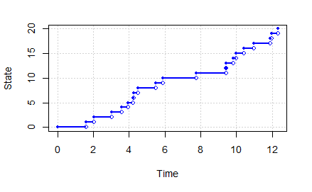

```r
points(time, N, pch=20, col='blue')
points(time[-1], N[-length(time)], pch=1, col='blue')
```

### Simulation 3.2 (Uniform Order Statistics).

First we need to prove the theoretical result. Consider a Poisson process {N(t), t ≥ 0}. Given that n events occurred by time t, the times at which the events occurred are distributed as the order statistics of a uniform distribution on (0, t).

```r
# Specifying parameters
t <- 10
lambda <- 2

# Specifying seed
set.seed(32114)

# Generating N(t)
njumps <- rpois(1, lambda*t)

# Defining stares
N <- 0:njumps

# Generating N(t) standard uniforms
u <- c()
u[1] <- 0

for(i in 2:(njumps+1))
  u[i] <- runif(1)

# Computing event times
time <- t*sort(u)

# Plotting trajectory
plot(time, N, type="n", xlab="Time", ylab="State",
panel.first = grid())
segments(time[-length(time)], N[-length(time)],
time[-1]-0.07, N[-length(time)], lwd=2, col="blue")
```

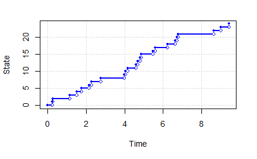

```r
points(time, N, pch=20, col="blue")
points(time[-1], N[-length(time)], pch=1, col="blue")
```

### 3.3 Applications of Poisson Process

We obtain the data from the Southern California Earthquake Data Center’s website: e https://service.scedc.caltech.edu/eq-catalogs/date_mag_loc.php.

```r
eq.data <- read.csv() # Falta el archivo

# Creating date-time variable
datetime <- as.POSIXct(paste(as.Date(eq.data$DATE), eq.data$TIME))

# COMPUTING LAG
datetime.lag <- c(0, head(datetime, -1))

# Computing interarrival times (in hours)
int.time <- (as.numeric(datetime) - as.numeric(datetime.lag)) / 3600

# Removing first value
int.time <- int.time[-1]

# removing immediate aftershocks (within 3 hours)
int <- int.time[int.time > 3]

# Plotting histogram
hist(int, main='', col='magenta', xlab='Interarrival Time')
```

[output not shown]

```r
#binning interarrival times
binned.int<- as.factor(ifelse(int<40,"1",
ifelse(int>=40 & int<80,"2",ifelse(int>=80 & int<120,"3", ifelse(int>=120 & int<160,"4",ifelse(int>=160 &
int<200,"5",
ifelse(int>=200 & int<240,"6","7")))))))
```

[output not shown]

```r
round(exp, 1)

# Computing chi-squared statistic
print(chi.sq <- sum((obs-exp)^2/ exp))

# Computing p-value
print(p.values <- 1-pchisq(chi.sq, df=5))
```

[output not shown]

The duration fo the playing time in an ice hockey game is $T=60$ minutes. Therefore, we obtain.
$$\mathbb{P}(game~ties) =
e^{-(1/10+1/12)(60)}\sum_{n=0}^{\infty}\frac{((1/10)(1/12)(60)^2)^n}{(n!)^2}$$
$$=e^{-11}\sum_{n=0}^{\infty}\frac{30^n}{(n!)^2} =
0.1166$$

We calculate the sum numerically in R. The sum converges after 15 terms

```r
sum <- 0

# Inicializo el calculo
for (n in 0:15)
  sum <- sum + 30^n / (factorial(n))^2

sum * exp(-11)
```

```
[1] 0.1165575
```

Further,
$$\mathbb{P}(team~A~wins) =
e^{-11}\sum_{n=0}^{\infty}\left[\frac{30^n}{n!}~.~\sum_{k=1}^{\infty}\frac{6^k}{(n+k)!}
\right] = 0.5590$$
R code given below computes this double sum numerically

```r
# Initializamos la variable
sum.n <- 0

# Iniciamos ciclos
for (n in 0:15){
  sum.k <- 0
  for (k in 1:15)
    sum.k <- sum.k + 6^k / factorial(n+k)
  sum.n <- sum.n + 30^n/factorial(n) *sum.k
}

sum.n*exp(-11)
```

[output not shown]

Finally,
$$\mathbb{P}(team~B~wins) =
e^{-11}\sum_{n=0}^\infty\left[\frac{30^n}{n!}~.~\sum_{k=1}^{\infty}\frac{5^{k}}{(n+k)!}\right]=0.3244$$
as the R code below computes

```r
# Inicilizamos la variable en 0
sum.n <- 0

# Iniciamos a realizar las sumatorias
for (n in 0:15){
  sum.k <- 0
  for (k in 1:15)
    sum.k <- sum.k+5^k/factorial(n+k)
  sum.n <- sum.n + 30^n/factorial(n)*sum.k
}

sum.n * exp(-11)
```

[output not shown]

# Exercies

### Exercise 3.1

Let $\{N(t), t \geq 0\}$ be a Poisson process with rate $\lambda$. Fin the joint probability distribution $\mathbb{P}(N(s) = m, N(t) = n)$, for any $t\geq s\geq 0$, adn $n\geq m \geq 0$

We use the independece and stationarity of increments of a Poisson process to derive the expression for the joint probability distribution. We write:
$$P(N(s))=m,N(t)=n) = P(N(t)-N(s)=
n-m, N(s)=m)$$
$$=P(N(t)-N(s)=n-m)
P(N(s) = m) = P(N(t-s) = n-m)P(N(s)=m)$$
$$=\frac{(\lambda(t-s))^{n-m}}{(n-m)!}e^{-\lambda(t-s)}~.~\frac{(\lambda
s)^m}{m!}e^{-\lambda s}=\frac{(t-s)^{n-m}s^{m}}{(n-m)!m!}\lambda^n
e^{-\lambda t}$$

$$=\begin{pmatrix}n \\ m \end{pmatrix}
\left(\frac{s}{t}\right)^{m} \left(1-\frac{s}{t}\right)^{n-m}
\frac{\lambda^n}{n!}e^{-\lambda t}$$

## Exercise 3.2

Show that for a Poisson process $\{N(t), t\geq 0\}$ with rate $\lambda$, the covariance between $N(s)$ is equal to $\lambda$ min(s,t), for any $s,t\geq 0$.

Assume that $s<t$. We computhe the covariance function, using the independence and stationarity of the increments. We have

$Cov(N(s), N(t)) = \mathbb{E}[N(s)N(t)] - \mathbb{E}[N(s)] \mathbb{E}[N(t)]$ $=\mathbb{E}[(N(t)-N(s) + N(s))] - \mathbb{E}[N(s)]\mathbb{E}[N(t)]$ $=\mathbb{E} [N(t)-N(s)N(s)] + \mathbb{E}[N(s)]^{2}- \mathbb{E}[N(s)]\mathbb{E}[N(t)]$ $=\mathbb{E}[N(t)-N(s)]\mathbb{E}[N(s)]+var[N(s)]+[\mathbb{E}(N(s))]^{2} - \mathbb{E}[N(s)]\mathbb{E}[N(t)]$ $\mathbb{E}[N(t-s)]\mathbb{E}[N(s)]+var[N(s)] + [\mathbb{E}(N(s))]^{2}-\mathbb{E}[N(s)]\mathbb{E}[N(t)]$ $=\lambda(t-s)\lambda s+\lambda s+ (\lambda s)^{2} - \lambda s\lambda t= \lambda s$

### Exercise 3.3

An insurance agent handles policyholders’claims. Claims are submitted on weekdays according to a poisson process with a rate $\lambda=5$ per day. a) If there were two claims submitted on Monday and three on Tuesday, what is the probability that by the end of the day on Friday there will be a total of 16 claims submitted that week?

$$P(N(5) = 16\mid N(1)=2,
N(2)-N(1)=3)$$
$$=\frac{P(N(5)-N(2)=11, N(2)-N(1)=3,
N(1)=2)}{P(N(2)-N(1)=3, N(1)=2)}$$
$$\frac{P(N(3)=11)P(N(1)=3)P(N(1)=2)}{P(N(1)=3)P(N(1)=2)}=P(N(3)=11)=
\frac{((5)(3))^{11}}{11!}e^{-(5)(3)}=0.0663$$

2. In the new calendar year, the agent opens for business on Monday, January 2. On what day does he expect to see the 100th claim?

Since $E(S_{100})=(100)\left(\frac{1}{5}\right) = 20$, the 100th claim is expected to be seen on the 20th business day, that is, on January 27th.

[output not shown]